# Project: Data visualization

This data set contains 113,937 loans with 81 variables on each loan, including loan amount, borrower rate (or interest rate), current loan status, borrower income, and many others.

The data dictionnary explains the meaning of each variable. The dataset is relatively wide with 81 columns. Therefore the first phase WRANGLING will consist in reading the data, assess the quality of the data, its completeness and its tidiness. Afterwards we will implement an exploratory and finally explanotory data visualization

> Example questions for the visualization are: What factors affect a loan’s outcome status? What affects the borrower’s APR or interest rate? Are there differences between loans depending on how large the original loan amount was? My questions will be stated in the data visualization parts

## Data Wrangling

### General Properties

- Gather, that is read the csv data
- Define general properties
- Assessing missing values and NaN
- Select the columns i will analyze
- Assess the tidiness of the CSV

```python
#I can iterate to verify the true type of each column and find the index of all interesting columns
for i, v in enumerate(df.columns):
    print(i, v , type(v))
```

```
0 ListingKey <class 'str'>
1 ListingNumber <class 'str'>
2 ListingCreationDate <class 'str'>
3 CreditGrade <class 'str'>
4 Term <class 'str'>
5 LoanStatus <class 'str'>
6 ClosedDate <class 'str'>
7 BorrowerAPR <class 'str'>
8 BorrowerRate <class 'str'>
9 LenderYield <class 'str'>
10 EstimatedEffectiveYield <class 'str'>
11 EstimatedLoss <class 'str'>
12 EstimatedReturn <class 'str'>
13 ProsperRating (numeric) <class 'str'>
14 ProsperRating (Alpha) <class 'str'>
```

[output cut: 66 more lines]

## Select the columns of interest

The columns will be extracted by using the indexes. We choose to focus on values which are

- Complete
- are the most financially speaking understandable
- are not entirely missing with too many NaN values

These are the columns I first choose to extract:

- ListingKey 113937 non-null object 0
- ListingNumber 113937 non-null int64 1
- ListingCreationDate 113937 non-null object 2
- Term 113937 non-null int64 4
- LoanStatus 113937 non-null object 5
- BorrowerAPR 113912 non-null float64 7
- BorrowerRate 113937 non-null float64 8
- LenderYield 113937 non-null float64 9
- BorrowerState 108422 non-null object 17
- Occupation 110349 non-null object 18
- EmploymentStatus 111682 non-null object 19
- EmploymentStatusDuration 106312 non-null float64 20
- IsBorrowerHomeowner 113937 non-null bool 21
- CurrentlyInGroup 113937 non-null bool 22
- CurrentDelinquencies 113240 non-null float64 35
- PublicRecordsLast10Years 113240 non-null float64 b38
- IncomeRange 113937 non-null object 47
- IncomeVerifiable 113937 non-null bool 48
- StatedMonthlyIncome 113937 non-null float64 49
- LoanMonthsSinceOrigination 113937 non-null int64 61
- LoanNumber 113937 non-null int64 62
- LoanOriginalAmount 113937 non-null int64 63
- LoanOriginationDate 113937 non-null object 64
- LoanOriginationQuarter 113937 non-null object 65
- MemberKey 113937 non-null object 66
- MonthlyLoanPayment 113937 non-null float64 67
- LP_CustomerPayments 113937 non-null float64 68
- LP_CustomerPrincipalPayments 113937 non-null float64 69
- LP_InterestandFees 113937 non-null float64 70
- LP_ServiceFees 113937 non-null float64 71
- LP_CollectionFees 113937 non-null float64 72
- LP_GrossPrincipalLoss 113937 non-null float64 73
- LP_NetPrincipalLoss 113937 non-null float64 74
- LP_NonPrincipalRecoverypayments 113937 non-null float64 75
- PercentFunded 113937 non-null float64 76
- Recommendations 113937 non-null int64 77
- InvestmentFromFriendsCount 113937 non-null int64 78
- InvestmentFromFriendsAmount 113937 non-null float64 79
- Investors 113937 non-null int64 80

### Selecting Multiple Ranges in Pandas

Selecting the columns for the mean dataframe was pretty straightforward - the columns we needed are selected using indexes an intervalls.

First, try creating the standard error dataframe on your own to see why doing this with just `loc` and `iloc` is an issue. Then, use this [stackoverflow link](https://stackoverflow.com/questions/41256648/select-multiple-ranges-of-columns-in-pandas-dataframe) to learn how to select multiple ranges in Pandas and try it below. By the way, to figure this out myself, I just found this link by googling "how to select multiple ranges df.iloc"

*Hint: You may have to import a new package!*

```python
# create dataframe by selecting available and consistend columns
print(df.shape)
df_selected = df2.iloc[:, np.r_[0:3, 4,5 ,7:10, 21, 34,38 , 47:50, 60:80]]
# view the first few rows to confirm this was successful
df_selected.head(3)
```

```
(113937, 81)
```

|  | ListingKey | ListingNumber | ListingCreationDate | Term | LoanStatus | BorrowerAPR | BorrowerRate | LenderYield | IsBorrowerHomeowner | TotalInquiries | PublicRecordsLast10Years | IncomeRange | IncomeVerifiable | StatedMonthlyIncome | LoanFirstDefaultedCycleNumber | LoanMonthsSinceOrigination | LoanNumber | LoanOriginalAmount | LoanOriginationDate | LoanOriginationQuarter | MemberKey | MonthlyLoanPayment | LP_CustomerPayments | LP_CustomerPrincipalPayments | LP_InterestandFees | LP_ServiceFees | LP_CollectionFees | LP_GrossPrincipalLoss | LP_NetPrincipalLoss | … |
| --- | --- | --- | --- | --- | --- | --- | --- | --- | --- | --- | --- | --- | --- | --- | --- | --- | --- | --- | --- | --- | --- | --- | --- | --- | --- | --- | --- | --- | --- | --- |
| 0 | 1021339766868145413AB3B | 193129 | 2007-08-26 19:09:29.263000000 | 36 | Completed | 0.16516 | 0.158 | 0.138 | True | 3.0 | 0.0 | $25,000-49,999 | True | 3083.333333 | NaN | 78 | 19141 | 9425 | 2007-09-12 00:00:00 | Q3 2007 | 1F3E3376408759268057EDA | 330.43 | 11396.14 | 9425.0 | 1971.14 | -133.18 | 0.0 | 0.0 | 0.0 | … |
| 1 | 10273602499503308B223C1 | 1209647 | 2014-02-27 08:28:07.900000000 | 36 | Current | 0.12016 | 0.092 | 0.082 | False | 5.0 | 1.0 | $50,000-74,999 | True | 6125.000000 | NaN | 0 | 134815 | 10000 | 2014-03-03 00:00:00 | Q1 2014 | 1D13370546739025387B2F4 | 318.93 | 0.00 | 0.0 | 0.00 | 0.00 | 0.0 | 0.0 | 0.0 | … |
| 2 | 0EE9337825851032864889A | 81716 | 2007-01-05 15:00:47.090000000 | 36 | Completed | 0.28269 | 0.275 | 0.240 | False | 1.0 | 0.0 | Not displayed | True | 2083.333333 | NaN | 86 | 6466 | 3001 | 2007-01-17 00:00:00 | Q1 2007 | 5F7033715035555618FA612 | 123.32 | 4186.63 | 3001.0 | 1185.63 | -24.20 | 0.0 | 0.0 | 0.0 | … |

### Assessing the data before the analysis

- ListingKey Unique key for each listing, same value as the 'key' used in the listing object in the API.
- ListingNumber The number that uniquely identifies the listing to the public as displayed on the website.
- ListingCreationDate The date the listing was created.
- Term The length of the loan expressed in months.
- LoanStatus The current status of the loan: Cancelled, Chargedoff, Completed, Current, Defaulted, FinalPaymentInProgress, PastDue. The PastDue status will be accompanied by a delinquency bucket.
- BorrowerAPR The Borrower's Annual Percentage Rate (APR) for the loan.
- BorrowerRate The Borrower's interest rate for this loan.
- DebtToIncomeRatio The debt to income ratio of the borrower at the time the credit profile was pulled. This value is Null if the debt to income ratio is not available. This value is capped at 10.01 (any debt to income ratio larger than 1000% will be returned as 1001%).
- IncomeRange The income range of the borrower at the time the listing was created.
- IncomeVerifiable The borrower indicated they have the required documentation to support their income.
- ScorexChangeAtTimeOfListing Borrower's credit score change at the time the credit profile was pulled. This will be the change relative to the borrower's last Prosper loan. This value will be null if the borrower had no prior loans.
- LoanCurrentDaysDelinquent The number of days delinquent.
- LoanFirstDefaultedCycleNumber The cycle the loan was charged off. If the loan has not charged off the value will be null.
- LoanMonthsSinceOrigination Number of months since the loan originated.
- LoanNumber Unique numeric value associated with the loan.
- LoanOriginalAmount The origination amount of the loan.
- LoanOriginationDate The date the loan was originated.
- LoanOriginationQuarter The quarter in which the loan was originated.
- MemberKey The unique key that is associated with the borrower. This is the same identifier that is used in the API member object.
- MonthlyLoanPayment The scheduled monthly loan payment.
- LP_CustomerPayments Pre charge-off cumulative gross payments made by the borrower on the loan. If the loan has charged off, this value will exclude any recoveries.
- LP_CustomerPrincipalPayments Pre charge-off cumulative principal payments made by the borrower on the loan. If the loan has charged off, this value will exclude any recoveries.
- LP_InterestandFees Pre charge-off cumulative interest and fees paid by the borrower. If the loan has charged off, this value will exclude any recoveries.
- LP_ServiceFees Cumulative service fees paid by the investors who have invested in the loan.
- LP_CollectionFees Cumulative collection fees paid by the investors who have invested in the loan.
- LP_GrossPrincipalLoss The gross charged off amount of the loan.
- LP_NetPrincipalLoss The principal that remains uncollected after any recoveries.
- LP_NonPrincipalRecoverypayments The interest and fee component of any recovery payments. The current payment policy applies payments in the following order: Fees, interest, principal.
- PercentFunded Percent the listing was funded.
- Recommendations Number of recommendations the borrower had at the time the listing was created.
- InvestmentFromFriendsCount Number of friends that made an investment in the loan.
- InvestmentFromFriendsAmount Dollar amount of investments that were made by friends.
- Investors The number of investors that funded the loan.

### Assessment

### Define my assessment

- Assessing missing values and NaN in the selection
- Assess the type of the selection
- Assess the tidiness of the selection

### Evaluation with code

```python
df_selected.describe()
```

|  | ListingNumber | Term | BorrowerAPR | BorrowerRate | LenderYield | TotalInquiries | PublicRecordsLast10Years | StatedMonthlyIncome | LoanFirstDefaultedCycleNumber | LoanMonthsSinceOrigination | LoanNumber | LoanOriginalAmount | MonthlyLoanPayment | LP_CustomerPayments | LP_CustomerPrincipalPayments | LP_InterestandFees | LP_ServiceFees | LP_CollectionFees | LP_GrossPrincipalLoss | LP_NetPrincipalLoss | LP_NonPrincipalRecoverypayments | PercentFunded | Recommendations | InvestmentFromFriendsCount | InvestmentFromFriendsAmount |
| --- | --- | --- | --- | --- | --- | --- | --- | --- | --- | --- | --- | --- | --- | --- | --- | --- | --- | --- | --- | --- | --- | --- | --- | --- | --- |
| count | 1.139370e+05 | 113937.000000 | 113912.000000 | 113937.000000 | 113937.000000 | 112778.000000 | 113240.000000 | 1.139370e+05 | 16952.000000 | 113937.000000 | 113937.000000 | 113937.00000 | 113937.000000 | 113937.000000 | 113937.000000 | 113937.000000 | 113937.000000 | 113937.000000 | 113937.000000 | 113937.000000 | 113937.000000 | 113937.000000 | 113937.000000 | 113937.000000 | 113937.000000 |
| mean | 6.278857e+05 | 40.830248 | 0.218828 | 0.192764 | 0.182701 | 5.584405 | 0.312646 | 5.608026e+03 | 16.268464 | 31.896882 | 69444.474271 | 8337.01385 | 272.475783 | 4183.079489 | 3105.536588 | 1077.542901 | -54.725641 | -14.242698 | 700.446342 | 681.420499 | 25.142686 | 0.998584 | 0.048027 | 0.023460 | 16.550751 |
| std | 3.280762e+05 | 10.436212 | 0.080364 | 0.074818 | 0.074516 | 6.429946 | 0.727868 | 7.478497e+03 | 9.005898 | 29.974184 | 38930.479610 | 6245.80058 | 192.697812 | 4790.907234 | 4069.527670 | 1183.414168 | 60.675425 | 109.232758 | 2388.513831 | 2357.167068 | 275.657937 | 0.017919 | 0.332353 | 0.232412 | 294.545422 |
| min | 4.000000e+00 | 12.000000 | 0.006530 | 0.000000 | -0.010000 | 0.000000 | 0.000000 | 0.000000e+00 | 0.000000 | 0.000000 | 1.000000 | 1000.00000 | 0.000000 | -2.349900 | 0.000000 | -2.349900 | -664.870000 | -9274.750000 | -94.200000 | -954.550000 | 0.000000 | 0.700000 | 0.000000 | 0.000000 | 0.000000 |
| 25% | 4.009190e+05 | 36.000000 | 0.156290 | 0.134000 | 0.124200 | 2.000000 | 0.000000 | 3.200333e+03 | 9.000000 | 6.000000 | 37332.000000 | 4000.00000 | 131.620000 | 1005.760000 | 500.890000 | 274.870000 | -73.180000 | 0.000000 | 0.000000 | 0.000000 | 0.000000 | 1.000000 | 0.000000 | 0.000000 | 0.000000 |
| 50% | 6.005540e+05 | 36.000000 | 0.209760 | 0.184000 | 0.173000 | 4.000000 | 0.000000 | 4.666667e+03 | 14.000000 | 21.000000 | 68599.000000 | 6500.00000 | 217.740000 | 2583.830000 | 1587.500000 | 700.840100 | -34.440000 | 0.000000 | 0.000000 | 0.000000 | 0.000000 | 1.000000 | 0.000000 | 0.000000 | 0.000000 |
| 75% | 8.926340e+05 | 36.000000 | 0.283810 | 0.250000 | 0.240000 | 7.000000 | 0.000000 | 6.825000e+03 | 22.000000 | 65.000000 | 101901.000000 | 12000.00000 | 371.580000 | 5548.400000 | 4000.000000 | 1458.540000 | -13.920000 | 0.000000 | 0.000000 | 0.000000 | 0.000000 | 1.000000 | 0.000000 | 0.000000 | 0.000000 |
| max | 1.255725e+06 | 60.000000 | 0.512290 | 0.497500 | 0.492500 | 379.000000 | 38.000000 | 1.750003e+06 | 44.000000 | 100.000000 | 136486.000000 | 35000.00000 | 2251.510000 | 40702.390000 | 35000.000000 | 15617.030000 | 32.060000 | 0.000000 | 25000.000000 | 25000.000000 | 21117.900000 | 1.012500 | 39.000000 | 33.000000 | 25000.000000 |

```python
df_selected.isna().sum()
```

```
ListingKey                             0
ListingNumber                          0
ListingCreationDate                    0
Term                                   0
LoanStatus                             0
BorrowerAPR                           25
BorrowerRate                           0
LenderYield                            0
IsBorrowerHomeowner                    0
TotalInquiries                      1159
PublicRecordsLast10Years             697
IncomeRange                            0
IncomeVerifiable                       0
StatedMonthlyIncome                    0
LoanFirstDefaultedCycleNumber      96985
LoanMonthsSinceOrigination             0
LoanNumber                             0
LoanOriginalAmount                     0
LoanOriginationDate                    0
LoanOriginationQuarter                 0
MemberKey                              0
MonthlyLoanPayment                     0
LP_CustomerPayments                    0
LP_CustomerPrincipalPayments           0
LP_InterestandFees                     0
LP_ServiceFees                         0
LP_CollectionFees                      0
LP_GrossPrincipalLoss                  0
LP_NetPrincipalLoss                    0
LP_NonPrincipalRecoverypayments        0
PercentFunded                          0
Recommendations                        0
InvestmentFromFriendsCount             0
InvestmentFromFriendsAmount            0
dtype: int64
```

### Visualization of missing values

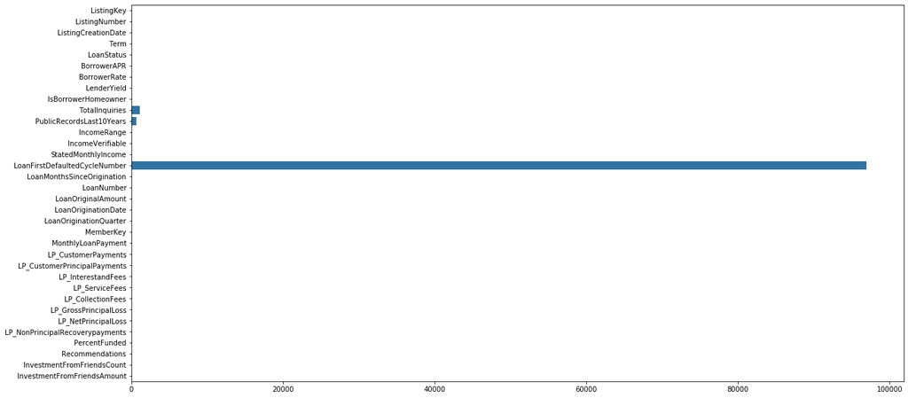

```python
na_counts = df_selected.isna().sum()
base_color = sns.color_palette()[0]
plt.figure(figsize=(20,10))
sns.barplot( na_counts,na_counts.index.values, color = base_color);
```

> Missing values should be observed, either interpreted, corrected or left out the analysis since we are analysing financial data.

### Types

```python
df_selected.dtypes
```

```
ListingKey                          object
ListingNumber                        int64
ListingCreationDate                 object
Term                                 int64
LoanStatus                          object
BorrowerAPR                        float64
BorrowerRate                       float64
LenderYield                        float64
IsBorrowerHomeowner                   bool
TotalInquiries                     float64
PublicRecordsLast10Years           float64
IncomeRange                         object
IncomeVerifiable                      bool
StatedMonthlyIncome                float64
LoanFirstDefaultedCycleNumber      float64
LoanMonthsSinceOrigination           int64
LoanNumber                           int64
LoanOriginalAmount                   int64
LoanOriginationDate                 object
LoanOriginationQuarter              object
MemberKey                           object
MonthlyLoanPayment                 float64
LP_CustomerPayments                float64
LP_CustomerPrincipalPayments       float64
LP_InterestandFees                 float64
LP_ServiceFees                     float64
LP_CollectionFees                  float64
LP_GrossPrincipalLoss              float64
LP_NetPrincipalLoss                float64
LP_NonPrincipalRecoverypayments    float64
PercentFunded                      float64
Recommendations                      int64
InvestmentFromFriendsCount           int64
InvestmentFromFriendsAmount        float64
dtype: object
```

```python
df_selected['IncomeVerifiable']
```

```
0         True
1         True
2         True
3         True
4         True
          ...
113932    True
113933    True
113934    True
113935    True
113936    True
Name: IncomeVerifiable, Length: 113937, dtype: bool
```

### Clean

Finishing the process of cleaning data at the very end of the data wrangling phase is important before starting with the analysis

- Clean the relevant issues boolean to numeric
- Handle the missing values
- LoanFirstDefaultedCycleNumber could be left off. Too many values are missing.
- The borrower rate is complete. The borrower APR Rate per year can be dropped.
- The dates need to be parsed

```python
#test
df_selected.isna().sum()
```

```
ListingKey                         0
ListingNumber                      0
ListingCreationDate                0
Term                               0
LoanStatus                         0
BorrowerRate                       0
LenderYield                        0
IsBorrowerHomeowner                0
TotalInquiries                     0
PublicRecordsLast10Years           0
IncomeRange                        0
IncomeVerifiable                   0
StatedMonthlyIncome                0
LoanMonthsSinceOrigination         0
LoanNumber                         0
LoanOriginalAmount                 0
LoanOriginationDate                0
LoanOriginationQuarter             0
MemberKey                          0
MonthlyLoanPayment                 0
LP_CustomerPayments                0
LP_CustomerPrincipalPayments       0
LP_InterestandFees                 0
LP_ServiceFees                     0
LP_CollectionFees                  0
LP_GrossPrincipalLoss              0
LP_NetPrincipalLoss                0
LP_NonPrincipalRecoverypayments    0
PercentFunded                      0
Recommendations                    0
InvestmentFromFriendsCount         0
InvestmentFromFriendsAmount        0
dtype: int64
```

# Phase 1: Explorative data visualization

### Definition: Define the objectives

- Get a fast overview of the correlation
- Get an overview of Nan and missing values

### Code: implement the steps

### Visaulizing the missing values after the cleaning phase

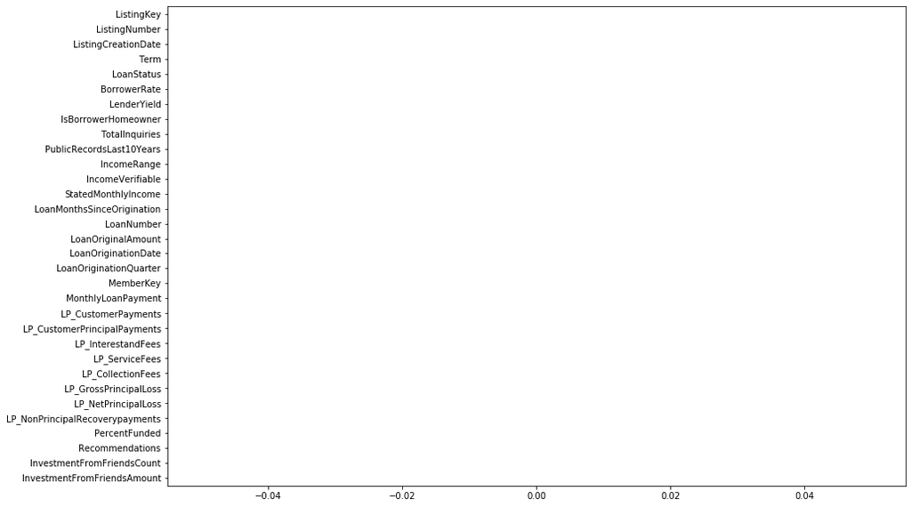

```python
# Missing values
na_counts = df_selected.isna().sum()
base_color = sns.color_palette()[0]
plt.figure(figsize=(15,10))
sns.barplot( na_counts,na_counts.index.values, color = base_color);
```

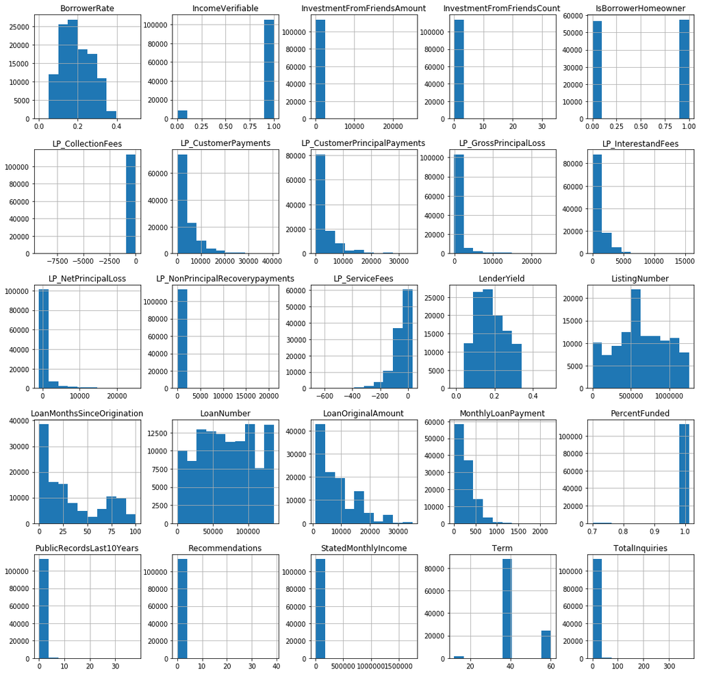

```python
#General visualization of the data
df_selected.hist(figsize=(18,18));
```

> The borrower rate is distributed between 0.1 and 0.4. Rare are the loan which are supported by friends. A significant amount of the customers's income level cannot be verified

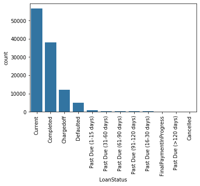

```python
base_color = sns.color_palette()[0]
sns.countplot(data = df_selected, x = 'LoanStatus', color = base_color, order = df_selected['LoanStatus'].value_counts().index)
plt.xticks(rotation = 90);
```

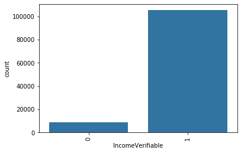

```python
base_color = sns.color_palette()[0]
sns.countplot(data = df_selected, x = 'IncomeVerifiable', color = base_color)
plt.xticks(rotation = 90);
```

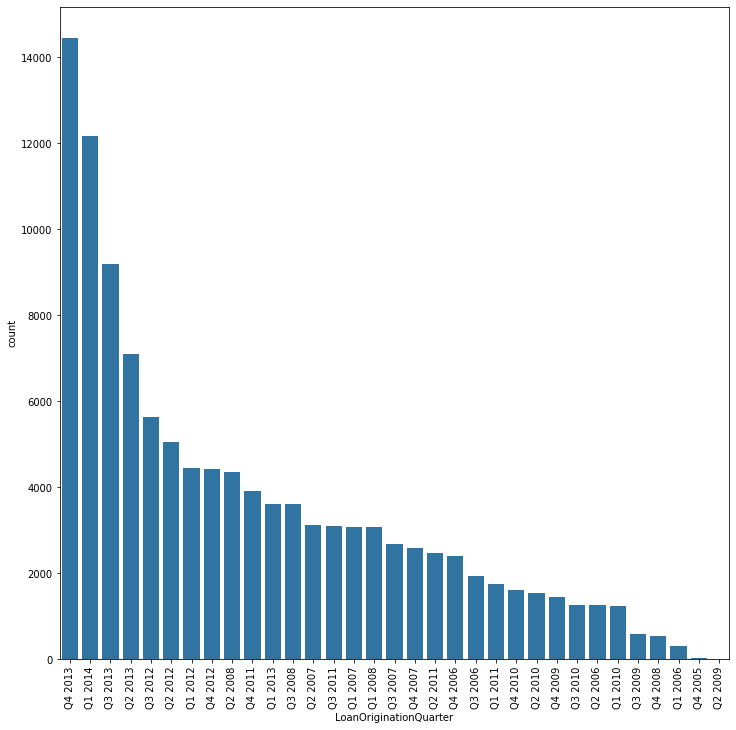

```python
base_color = sns.color_palette()[0]
plt.figure(figsize=(12,12))
sns.countplot(data = df_selected, x = 'LoanOriginationQuarter', color = base_color ,order = df_selected['LoanOriginationQuarter'].value_counts().index)
plt.xticks(rotation = 90);
```

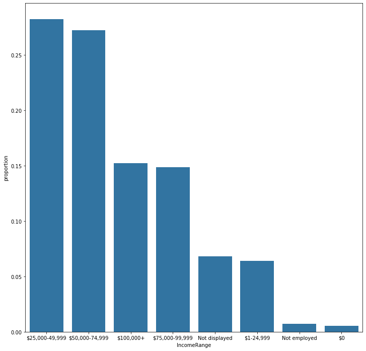

```python
# get proportion taken by most common group for derivation
# of tick marks
n_points = df_selected.shape[0]
max_count = df_selected['IncomeRange'].value_counts().max()
max_prop = max_count / n_points

# generate tick mark locations and names
tick_props = np.arange(0, max_prop, 0.05)
tick_names = ['{:0.2f}'.format(v) for v in tick_props]

# create the plot
base_color = sns.color_palette()[0]
plt.figure(figsize=(12,12))
sns.countplot(data = df_selected, x = 'IncomeRange', color = base_color , order = df_selected['IncomeRange'].value_counts().index)
plt.yticks(tick_props * n_points, tick_names)
plt.ylabel('proportion');
```

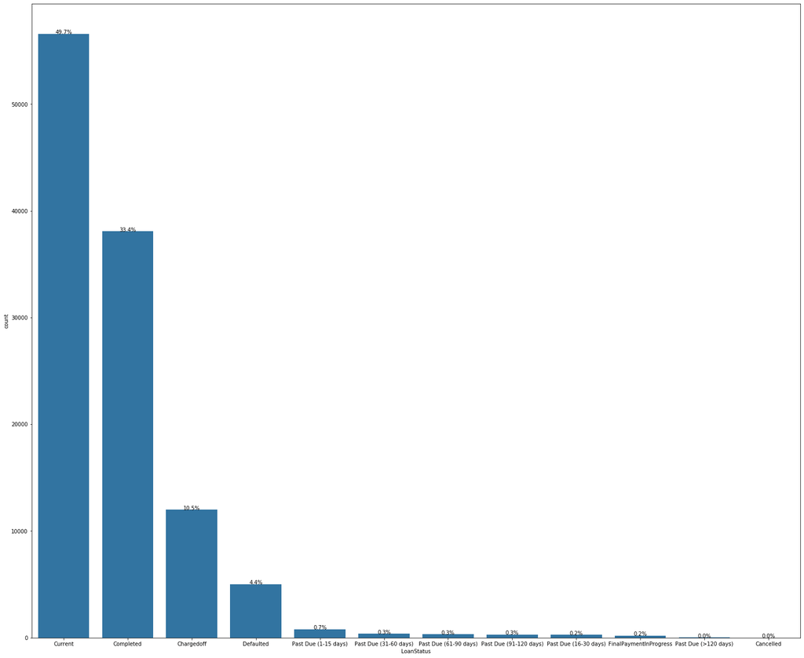

```python
#create the plot
base_color = sns.color_palette()[0]
plt.figure(figsize=(26,22))

sns.countplot(data = df_selected, x = 'LoanStatus', color = base_color,
             order = df_selected['LoanStatus'].value_counts().index)

# add annotations
n_points = df_selected.shape[0]
cat_counts = df_selected['LoanStatus'].value_counts()
locs, labels = plt.xticks() # get the current tick locations and labels

# loop through each pair of locations and labels
for loc, label in zip(locs, labels):

    # get the text property for the label to get the correct count
    count = cat_counts[label.get_text()]
    pct_string = '{:0.1f}%'.format(100*count/n_points)

    # print the annotation just below the top of the bar
    plt.text(loc, count-8, pct_string, ha = 'center', color = 'black')
```

# Income range and term related correlations

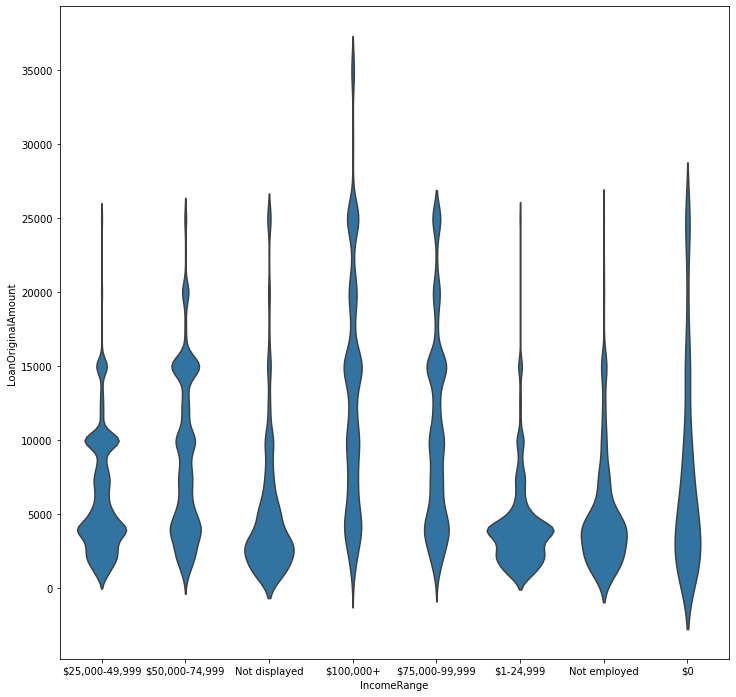

```python
fig, axes = plt.subplots(nrows=1, ncols=1,figsize=(12,12), sharey= False)
sns.violinplot(data = df_selected, x = 'IncomeRange', y = 'LoanOriginalAmount', color = base_color,
              inner = None , showmedians = True);
```

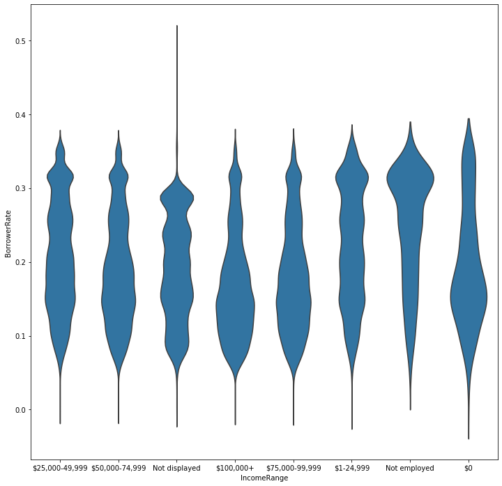

```python
base_color = sns.color_palette()[0]

fig, axes = plt.subplots(nrows=1, ncols=1,figsize=(12,12), sharey= False)

sns.violinplot(data = df_selected, x = 'IncomeRange', y = 'BorrowerRate', color = base_color,
              inner = None , showmedians = True);
```

> Only indidivuals who earn more that 100.000 dollars per year received a total loan of more than 30000 dollars People who earn between 50000 and 75000 dollars mostly have a total loan of 15000 dollars At first the borrower rate seem larger for people who are not employed

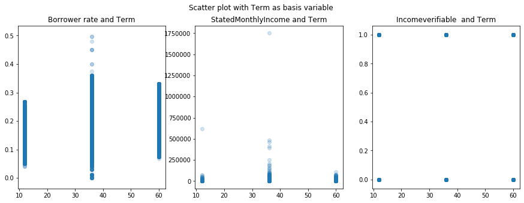

```python
#scatter
fig, axs = plt.subplots(1, 3,figsize=(15,5), sharey= False)
#scatter
#plt.figure(figsize=(20,20))
axs[0].scatter(data = df_selected, x = 'Term', y = 'BorrowerRate', alpha = 1/5);
axs[0].set_title('Borrower rate and Term')


axs[1].scatter(data = df_selected, x = 'Term', y = 'StatedMonthlyIncome', alpha = 1/5);
axs[1].set_title('StatedMonthlyIncome and Term')

axs[2].scatter(data = df_selected, x = 'Term', y = 'IncomeVerifiable', alpha = 1/5);
axs[2].set_title('Incomeverifiable  and Term')



fig.suptitle('Scatter plot with Term as basis variable');
```

### There are three categories of terms available: 1 year, 3 years (36 months) and 5 years. At first glance there is no correlation observable.

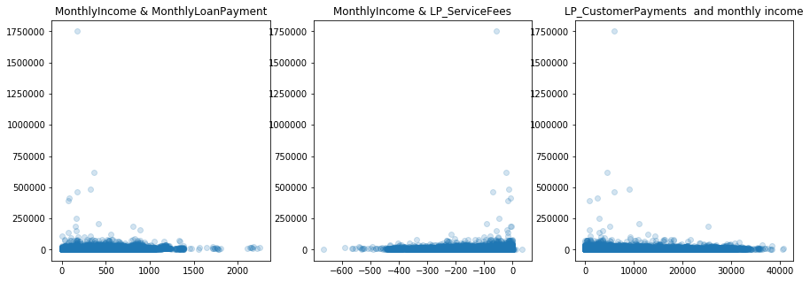

```python
#scatter
fig, axs = plt.subplots(1, 3,figsize=(15,5), sharey= False)
#scatter
#plt.figure(figsize=(20,20))
axs[0].scatter(data = df_selected, y = 'StatedMonthlyIncome', x = 'MonthlyLoanPayment', alpha = 1/5);
axs[0].set_title('MonthlyIncome & MonthlyLoanPayment')


axs[1].scatter(data = df_selected, x = 'LP_ServiceFees', y = 'StatedMonthlyIncome', alpha = 1/5);
axs[1].set_title('MonthlyIncome & LP_ServiceFees')

axs[2].scatter(data = df_selected, x = 'LP_CustomerPayments', y = 'StatedMonthlyIncome', alpha = 1/5);
axs[2].set_title('LP_CustomerPayments  and monthly income')
```

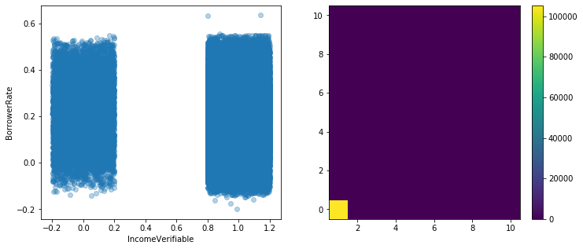

```python
plt.figure(figsize = [12, 5])

# left plot: scatterplot of discrete data with jitter and transparency
plt.subplot(1, 2, 1)
sns.regplot(data = df_selected, x = 'IncomeVerifiable', y = 'BorrowerRate', fit_reg = False,
           x_jitter = 0.2, y_jitter = 0.2, scatter_kws = {'alpha' : 1/3})

# right plot: heat map with bin edges between values
plt.subplot(1, 2, 2)
bins_x = np.arange(0.5, 10.5+1, 1)
bins_y = np.arange(-0.5, 10.5+1, 1)
plt.hist2d(data = df, x = 'IncomeVerifiable', y = 'BorrowerRate',
           bins = [bins_x, bins_y])
plt.colorbar();
```

### Clustered bar

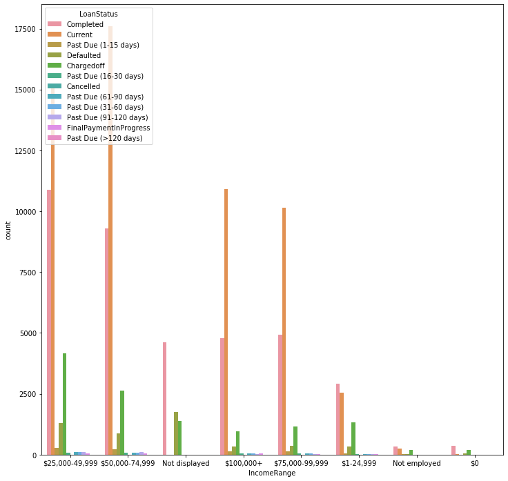

```python
plt.figure(figsize = [12, 12])
sns.countplot(data = df_selected, x = 'IncomeRange', hue = 'LoanStatus');
```

# Justice and loan related conditions

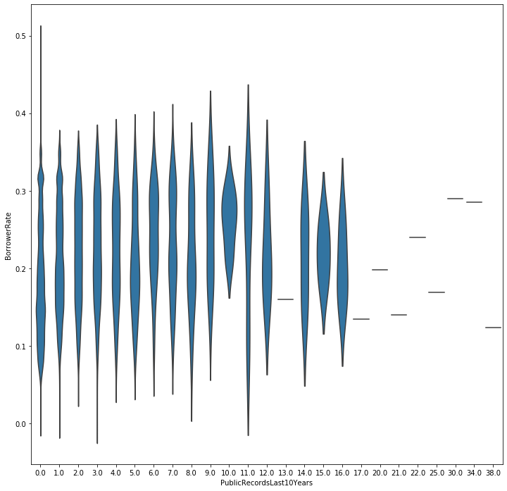

```python
base_color = sns.color_palette()[0]

fig, axes = plt.subplots(nrows=1, ncols=1,figsize=(12,12), sharey= False)

sns.violinplot(data = df_selected, y = 'BorrowerRate', x = 'PublicRecordsLast10Years', color = base_color,
              inner = None , showmedians = True);
```

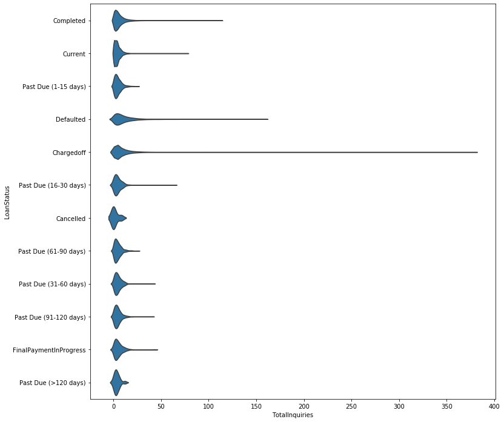

```python
base_color = sns.color_palette()[0]

fig, axes = plt.subplots(nrows=1, ncols=1,figsize=(12,12), sharey= False)

sns.violinplot(data = df_selected, y = 'LoanStatus', x = 'TotalInquiries', color = base_color,
              inner = None , showmedians = True);
```

### I can violin plots to visualize the correlation between a quantitative and a qualitative variable. People with cahrgeoff tend to have a larger number of total inquiries. The number of last published recorrds during the last years do not affect the borrower interest rate.

# Phase 2: Explanatory data visualization

### What factors affect a loan’s outcome status?

```python
df_reduced = df_selected.copy()
```

```python
df_reduced.drop(columns=['ListingNumber','ListingKey','LenderYield','InvestmentFromFriendsCount', 'InvestmentFromFriendsAmount','Recommendations','LP_NonPrincipalRecoverypayments', 'MemberKey','LP_CollectionFees','LP_GrossPrincipalLoss'] ,inplace =True)
df_reduced.tail(6)
```

[output not shown]

```python
df_reduced_loanStatus = df_reduced.copy()

df_reduced_loanStatus= df_reduced_loanStatus.drop(columns=['ListingCreationDate', 'LP_CustomerPayments','PercentFunded','LoanMonthsSinceOrigination','LoanOriginationDate','LoanOriginationQuarter'] ,inplace =True)
df_reduced_loanStatus
#df_reduced_loanStatus.infos()
#scatter(data = df_reduced_loanStatus, y = 'StatedMonthlyIncome', x = 'MonthlyLoanPayment', alpha = 1/5);
```

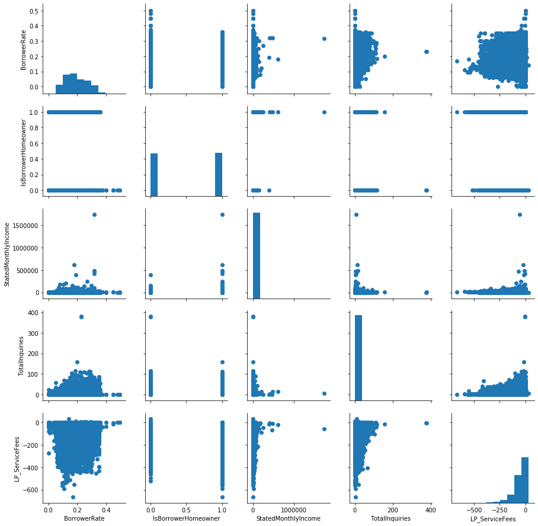

```python
g = sns.PairGrid(data = df_reduced, vars = [ 'BorrowerRate', 'IsBorrowerHomeowner','StatedMonthlyIncome','TotalInquiries','LP_ServiceFees'])
g.map_diag(plt.hist)
g.map_offdiag(plt.scatter)
```

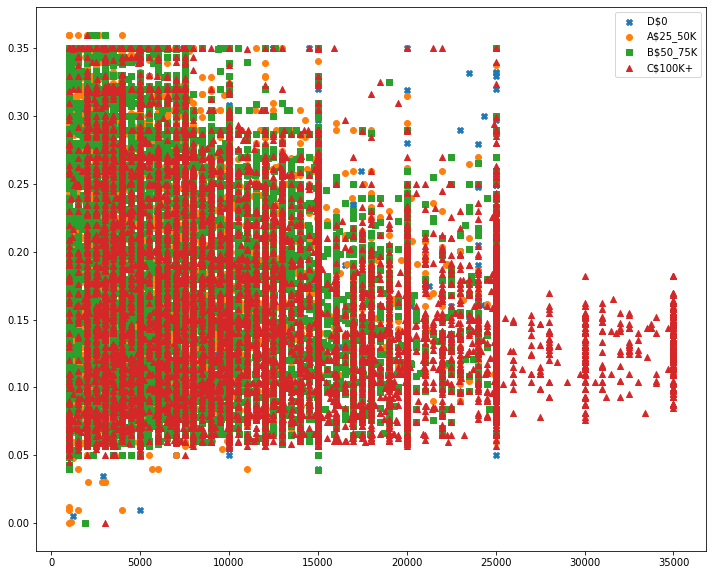

```python
cat_markers = [
                ['$0', 'X'],
               ['$25,000-49,999', 'o'],
               ['$50,000-74,999', 's'],
               ['$100,000+', '^']

              ]
plt.figure(figsize = [12, 10])
for cat, marker in cat_markers:
    df_reduced = df[df['IncomeRange'] == cat]
    plt.scatter(data = df_reduced, x = 'LoanOriginalAmount', y = 'BorrowerRate', marker = marker)

plt.legend(['D$0','A$25_50K','B$50_75K','C$100K+'])
```

## Do the criminal record and the income affect the interest rate? In other words: how do the finance institution evaluate the customer ?

```python
df_reduced.groupby('IsBorrowerHomeowner').mean()
```

| IsBorrowerHomeowner | Term | BorrowerRate | TotalInquiries | PublicRecordsLast10Years | IncomeVerifiable | StatedMonthlyIncome | LoanMonthsSinceOrigination | LoanNumber | LoanOriginalAmount | MonthlyLoanPayment | LP_CustomerPayments | LP_CustomerPrincipalPayments | LP_InterestandFees | LP_ServiceFees | LP_NetPrincipalLoss | PercentFunded |
| --- | --- | --- | --- | --- | --- | --- | --- | --- | --- | --- | --- | --- | --- | --- | --- | --- |
| 0 | 39.931632 | 0.202912 | 5.06410 | 0.373439 | 0.906764 | 4551.248765 | 34.503728 | 66456.536584 | 7033.868294 | 237.536436 | 3725.927670 | 2739.332684 | 986.594986 | -47.155797 | 622.781547 | 0.998687 |
| 1 | 41.712934 | 0.182796 | 5.98288 | 0.249139 | 0.940760 | 6646.067281 | 29.336250 | 72379.440238 | 9617.056561 | 306.795708 | 4632.126682 | 3465.248237 | 1166.878445 | -62.161283 | 739.019869 | 0.998482 |

```python
df_reduced.groupby('IncomeVerifiable').mean()
```

| IncomeVerifiable | Term | BorrowerRate | IsBorrowerHomeowner | TotalInquiries | PublicRecordsLast10Years | StatedMonthlyIncome | LoanMonthsSinceOrigination | LoanNumber | LoanOriginalAmount | MonthlyLoanPayment | LP_CustomerPayments | LP_CustomerPrincipalPayments | LP_InterestandFees | LP_ServiceFees | LP_NetPrincipalLoss | PercentFunded |
| --- | --- | --- | --- | --- | --- | --- | --- | --- | --- | --- | --- | --- | --- | --- | --- | --- |
| 0 | 39.360941 | 0.218716 | 0.392779 | 4.441919 | 0.261160 | 5022.281482 | 27.406737 | 71987.494982 | 7111.896413 | 252.138981 | 3829.994227 | 2713.582053 | 1116.412173 | -48.655136 | 907.949387 | 0.997847 |
| 1 | 40.951248 | 0.190627 | 0.513670 | 5.617006 | 0.314816 | 5656.262596 | 32.266653 | 69235.052162 | 8437.904368 | 274.150554 | 4212.156665 | 3137.814715 | 1074.341950 | -55.225558 | 662.765457 | 0.998644 |